# PRE-PROCESSING: TRAFFIC DATA

### Table of Contents

- 1 - Objectives
- 2 - Setup
- 3 - Helper Functions
- 4 - Download Data
- 5 - Understanding the Data
- 6 - Image and Mask Pre-processing
  - 6.1. - Image Pre-processing
  - 6.2. - Mask Pre-processing
  - 6.3. - Putting everything together
- 7 - Creating TF Datasets
- 8 - References

## **1. Introduction**

In this notebook, we demonstrate how to prepare image segmentation data for model training using a more realistic dataset focused on traffic scenes. Unlike synthetic examples, real-world data comes with challenges such as varying image sizes, noisy labels, and the need for efficient input pipelines.

We will walk through:

Loading image–mask pairs

Resizing and normalizing inputs

One-hot encoding the label masks

Building a tf.data.Dataset pipeline

This preprocessing workflow is essential for training accurate and efficient segmentation models on real-world tasks like road understanding, vehicle detection, and lane marking segmentation.

## **2. Setup**

```python
import os
import zipfile
import PIL.Image, PIL.ImageFont, PIL.ImageDraw
from PIL import Image
import numpy as np
import tensorflow as tf
from matplotlib import pyplot as plt
import tensorflow_datasets as tfds
import seaborn as sns
import cv2
```

```python
tf.random.set_seed(5)
```

```python
from dataclasses import dataclass

# for default values
@dataclass
class DataConfig:
    batch_size: int = 32
    width: int = 128
    height: int = 128

G = DataConfig()
```

## **3. Helper Functions**

```python
def show_image(img, title=None):
    """
    Display a PIL Image or a NumPy array with Matplotlib.
    """
    if isinstance(img, Image.Image):
        arr = np.array(img)
    else:
        arr = img  # assume it's already a NumPy array

    plt.imshow(arr)
    plt.axis('off')
    if title:
        plt.title(title)
    plt.show()
```

## **4. Download Data**

```python
#!pip install gdown
```

```python
# download the dataset (zipped file)
#!mkdir data
#!gdown --id 0B0d9ZiqAgFkiOHR1NTJhWVJMNEU -O data/fcnn-dataset.zip
```

```python
# extract the downloaded dataset to a local directory: /tmp/fcnn
local_zip = 'data/fcnn-dataset.zip'
zip_ref = zipfile.ZipFile(local_zip, 'r')
zip_ref.extractall('data/fcnn')
zip_ref.close()
```

```python
!ls data/fcnn/dataset1/
```

```
annotations_prepped_test   images_prepped_test
annotations_prepped_train  images_prepped_train
```

```python
train_img_dir = "data/fcnn/dataset1/images_prepped_train"
test_img_dir = "data/fcnn/dataset1/images_prepped_test"
train_annotation_dir = "data/fcnn/dataset1/annotations_prepped_train"
test_annotation_dir = "data/fcnn/dataset1/annotations_prepped_test"
```

## **5. Understanding the data**

The dataset contains folders for images and annotations.

- The *images* contain the video frames.
- The *annotations* contain the pixel-wise label maps.
  - Each label map has the shape `(height, width , 1)` with each point in this space denoting the corresponding pixel's class.

Classes are in the range `[0, 11]` (i.e. 12 classes) and the pixel labels correspond to these classes:

| Value | Class Name |
| --- | --- |
| 0 | sky |
| 1 | building |
| 2 | column/pole |
| 3 | road |
| 4 | side walk |
| 5 | vegetation |
| 6 | traffic light |
| 7 | fence |
| 8 | vehicle |
| 9 | pedestrian |
| 10 | byciclist |
| 11 | void |

For example, if a pixel is part of a road, then that point will be labeled `3` in the label map.

```python
# pixel labels in the video frames
class_names = ['sky', 'building','column/pole', 'road', 'side walk', 'vegetation', 'traffic light',
               'fence', 'vehicle',
               'pedestrian', 'byciclist', 'void']

num_classes = len(class_names)
```

Let's visualize images and annotations

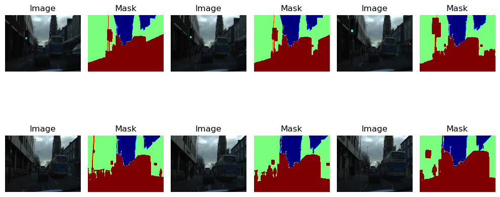

```python
# Number of samples to plot
num_samples_to_show = 6  # Multiple of 3 for even rows

# Get sample filenames
image_filenames = sorted(os.listdir(train_img_dir))[:num_samples_to_show]
mask_filenames = sorted(os.listdir(train_annotation_dir))[:num_samples_to_show]

# Plot settings
pairs_per_row = 3
fig, axs = plt.subplots(num_samples_to_show // pairs_per_row, pairs_per_row * 2,
                        figsize=(10,6))

for i, (img_file, mask_file) in enumerate(zip(image_filenames, mask_filenames)):
    # Load image and mask
    img = cv2.imread(os.path.join(train_img_dir, img_file))
    img = cv2.cvtColor(img, cv2.COLOR_BGR2RGB)
    mask = cv2.imread(os.path.join(train_annotation_dir, mask_file), cv2.IMREAD_GRAYSCALE)

    row = i // pairs_per_row
    col = (i % pairs_per_row) * 2

    axs[row, col].imshow(img)
    axs[row, col].set_title("Image")
    axs[row, col].axis("off")

    axs[row, col + 1].imshow(mask, cmap='jet', vmin=0, vmax=2)
    axs[row, col + 1].set_title("Mask")
    axs[row, col + 1].axis("off")

plt.tight_layout()
plt.show()
```

## **6. Image and Mask Pre-processing**

### **6.1. Image Pre-processing**

We will

- Read the image
- Resize to the desired size.
- Normalize pixel values to [-1, 1]

We will take one image as an example.

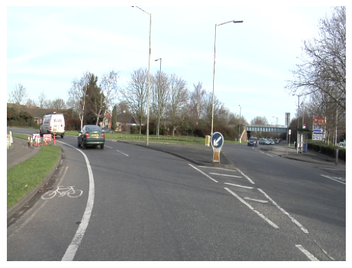

```python
img1_path = train_img_dir  + "/0006R0_f00930.png"
img1 = Image.open(img1_path)
show_image(img1)
```

```python
# read image
img_raw = tf.io.read_file(img1_path)
```

```python
# decode the image
image = tf.image.decode_png(img_raw, channels=3)
image.shape, image
```

```
(TensorShape([360, 480, 3]),
 <tf.Tensor: shape=(360, 480, 3), dtype=uint8, numpy=
 array([[[235, 255, 255],
         [235, 255, 255],
         [234, 255, 255],
         ...,
         [183, 190, 205],
         [237, 245, 252],
         [168, 185, 205]],

        [[235, 255, 255],
         [235, 255, 255],
         [235, 255, 255],
         ...,
         [159, 168, 184],
         [216, 226, 234],
         [229, 241, 248]],

        [[237, 255, 255],
         [236, 255, 255],
         [236, 255, 255],
         ...,
         [216, 223, 232],
         [161, 174, 184],
         [251, 254, 255]],

        ...,

        [[101, 101,  99],
         [107, 107, 106],
         [105, 105, 105],
         ...,
         [104, 105, 103],
         [119, 120, 116],
         [117, 118, 115]],

        [[ 96,  96,  97],
         [ 98,  98,  98],
         [102, 102, 102],
         ...,
         [111, 112, 110],
         [101, 102,  98],
         [101, 102, 101]],

        [[ 88,  88,  90],
         [ 92,  92,  94],
         [ 92,  92,  94],
         ...,
         [116, 117, 113],
         [105, 106, 104],
         [ 99, 100, 100]]], dtype=uint8)>)
```

We can see that each image has a shape of 360x480x3 (Color images of 360x480). We will resize it to 128x128x3.

```python
image = tf.image.resize(image, (G.height, G.width))
image.shape
```

```
TensorShape([128, 128, 3])
```

```python
# Normalize pixel values to [-1, 1]
image = tf.cast(image, tf.float32) / 127.5 - 1.0
image
```

[output not shown]

### **6.2. Mask Pre-processing**

We will:

- Resize all input images and label maps to a fixed size (default: 128 × 128 pixels).
- One-hot encode the label maps:
  - Original label maps have shape (height, width, 1) with integer class values.
  - We'll convert them to shape (height, width, num_classes), where each channel corresponds to a class.
  - Each pixel will be encoded as a one-hot vector across the class channels.
- Resize the height and width of the input images and label maps (128 x 128 px by default)
- Reshape the label maps from `(height, width, 1)` to `(height, width, num_classes)` with each slice along the third axis having `1` if it belongs to the class corresponding to that slice's index else `0`. For example, if a pixel is part of a road, then using the table above, that point at slice #3 will be labeled `1` and it will be `0` in all other slices. To illustrate using simple arrays:

```
# if we have a label map with 3 classes...
n_classes = 3
# and this is the original annotation...
orig_annotation = [0 1 2]
# then the reshaped annotation will have 3 slices and its contents will look like this:
reshaped_annotation = [
  [1, 0, 0],  # class 0
  [0, 1, 0],  # class 1
  [0, 0, 1],  # class 2
]
```

In this example num_classes = 12.

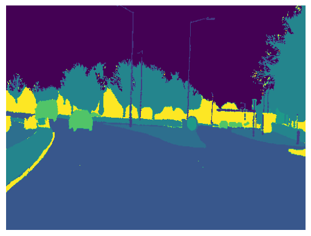

```python
annotation1_path = train_annotation_dir  + "/0006R0_f00930.png"
annotation1 = Image.open(annotation1_path)
show_image(annotation1)
```

```python
# read and decode annotation
annotation_raw = tf.io.read_file(annotation1_path)
annotation = tf.image.decode_jpeg(annotation_raw)

type(annotation), annotation.shape
```

```
(tensorflow.python.framework.ops.EagerTensor, TensorShape([360, 480, 1]))
```

```python
annotation
```

```
<tf.Tensor: shape=(360, 480, 1), dtype=uint8, numpy=
array([[[0],
        [0],
        [0],
        ...,
        [5],
        [5],
        [5]],

       [[0],
        [0],
        [0],
        ...,
        [5],
        [5],
        [5]],

       [[0],
        [0],
        [0],
        ...,
        [5],
        [5],
        [5]],

       ...,

       [[3],
        [3],
        [3],
        ...,
        [3],
        [3],
        [3]],

       [[3],
        [3],
        [3],
        ...,
        [3],
        [3],
        [3]],

       [[3],
        [3],
        [3],
        ...,
        [3],
        [3],
        [3]]], dtype=uint8)>
```

We can see it contains values between 0 and 11 (representing each class) for each of the 360×480 pixels.

```python
# resize
annotation = tf.image.resize(annotation, (G.height, G.width), method='nearest')  # Keep class labels intact
annotation.shape
```

```
TensorShape([128, 128, 1])
```

```python
# cast
annotation = tf.cast(annotation, tf.int32)
```

```python
# remove channel dimension (H, W, 1) -> (H, W)
annotation = tf.squeeze(annotation, axis=-1)
annotation.shape
```

```
TensorShape([128, 128])
```

```python
# Convert annotation to one-hot format: shape becomes (H, W, num_classes)
annotation = tf.one_hot(annotation, depth=num_classes)
annotation.shape, annotation
```

```
(TensorShape([128, 128, 12]),
 <tf.Tensor: shape=(128, 128, 12), dtype=float32, numpy=
 array([[[1., 0., 0., ..., 0., 0., 0.],
         [1., 0., 0., ..., 0., 0., 0.],
         [1., 0., 0., ..., 0., 0., 0.],
         ...,
         [1., 0., 0., ..., 0., 0., 0.],
         [0., 0., 0., ..., 0., 0., 0.],
         [0., 0., 0., ..., 0., 0., 0.]],

        [[1., 0., 0., ..., 0., 0., 0.],
         [1., 0., 0., ..., 0., 0., 0.],
         [1., 0., 0., ..., 0., 0., 0.],
         ...,
         [1., 0., 0., ..., 0., 0., 0.],
         [0., 0., 0., ..., 0., 0., 0.],
         [0., 0., 0., ..., 0., 0., 0.]],

        [[1., 0., 0., ..., 0., 0., 0.],
         [1., 0., 0., ..., 0., 0., 0.],
         [1., 0., 0., ..., 0., 0., 0.],
         ...,
         [0., 0., 0., ..., 0., 0., 1.],
         [0., 0., 0., ..., 0., 0., 0.],
         [0., 0., 0., ..., 0., 0., 0.]],

        ...,

        [[0., 0., 0., ..., 0., 0., 0.],
         [0., 0., 0., ..., 0., 0., 0.],
         [0., 0., 0., ..., 0., 0., 0.],
         ...,
         [0., 0., 0., ..., 0., 0., 0.],
         [0., 0., 0., ..., 0., 0., 0.],
         [0., 0., 0., ..., 0., 0., 0.]],

        [[0., 0., 0., ..., 0., 0., 0.],
         [0., 0., 0., ..., 0., 0., 0.],
         [0., 0., 0., ..., 0., 0., 0.],
         ...,
         [0., 0., 0., ..., 0., 0., 0.],
         [0., 0., 0., ..., 0., 0., 0.],
         [0., 0., 0., ..., 0., 0., 0.]],

        [[0., 0., 0., ..., 0., 0., 0.],
         [0., 0., 0., ..., 0., 0., 0.],
         [0., 0., 0., ..., 0., 0., 0.],
         ...,
         [0., 0., 0., ..., 0., 0., 0.],
         [0., 0., 0., ..., 0., 0., 0.],
         [0., 0., 0., ..., 0., 0., 0.]]], dtype=float32)>)
```

### **6.3. Putting everything together**

We can combine image and mask pre-processing in one function.

```python
def map_filename_to_image_and_mask(t_filename, a_filename, height=G.height, width=G.width, num_classes=num_classes):
    """
    Reads and preprocesses an image and its corresponding segmentation mask from given file paths.

    Args:
        t_filename (tf.Tensor or str): Path to the input image file.
        a_filename (tf.Tensor or str): Path to the corresponding annotation (mask) file.
        height (int): Target height to resize the image and mask. Defaults to G.height.
        width (int): Target width to resize the image and mask. Defaults to G.width.
        num_classes (int): Number of segmentation classes for one-hot encoding. Defaults to num_classes.

    Returns:
        image (tf.Tensor): Preprocessed image tensor of shape (height, width, 3), normalized to [-1, 1].
        annotation (tf.Tensor): One-hot encoded mask tensor of shape (height, width, num_classes).
    """

    # Read and decode the image (3 channels)
    img_raw = tf.io.read_file(t_filename)
    image = tf.image.decode_png(img_raw, channels=3)
    image = tf.image.resize(image, (height, width))  # Resize image to desired size
    image = tf.cast(image, tf.float32) / 127.5 - 1.0  # Normalize pixel values to [-1, 1]

    # Read and decode the annotation mask (1 channel)
    anno_raw = tf.io.read_file(a_filename)
    annotation = tf.image.decode_png(anno_raw, channels=1)
    annotation = tf.image.resize(annotation, (height, width), method='nearest')  # Keep class labels intact
    annotation = tf.cast(annotation, tf.int32)
    annotation = tf.squeeze(annotation, axis=-1)  # Remove channel dimension (H, W, 1) -> (H, W)

    # Convert annotation to one-hot format: shape becomes (H, W, num_classes)
    annotation = tf.one_hot(annotation, depth=num_classes)

    return image, annotation
```

## **7. Creating TF Datasets**

First, we need a function that returns sorted file paths for images and their corresponding segmentation masks (label maps).

```python
def get_dataset_slice_paths(image_dir, label_map_dir):
    '''
    Returns sorted paths to image and mask files.
    '''
    image_file_list = sorted(os.listdir(image_dir))
    label_map_file_list = sorted(os.listdir(label_map_dir))

    image_paths = [os.path.join(image_dir, fname) for fname in image_file_list]
    label_map_paths = [os.path.join(label_map_dir, fname) for fname in label_map_file_list]

    return image_paths, label_map_paths
```

```python
def get_dataset(image_paths, label_map_paths, batch_size = G.batch_size, training=True):
  '''
    Args:
        image_paths (list of str): Paths to each image file in the dataset.
        label_map_paths (list of str): Paths to each label map file.
        batch_size (int): Number of samples per batch.
        training (bool): Whether the dataset is for training (enables shuffling).

    Returns:
        tf.data.Dataset: A dataset yielding batches of preprocessed images and masks.
  '''
  training_dataset = tf.data.Dataset.from_tensor_slices((image_paths, label_map_paths))
  training_dataset = training_dataset.map(map_filename_to_image_and_mask)
  if training:
      training_dataset = training_dataset.shuffle(100, reshuffle_each_iteration=True)
  training_dataset = training_dataset.batch(batch_size)

  return training_dataset
```

```python
# get the paths to the images
training_image_paths, training_label_map_paths = get_dataset_slice_paths(train_img_dir, train_annotation_dir)
test_image_paths, test_label_map_paths = get_dataset_slice_paths(test_img_dir, test_annotation_dir)

# generate the train and val sets
training_dataset = get_dataset(training_image_paths, training_label_map_paths)
validation_dataset = get_dataset(test_image_paths, test_label_map_paths, training=False)
```

```python
for x, y in training_dataset.take(1):
    print(x.shape, y.shape)
```

```
(32, 128, 128, 3) (32, 128, 128, 12)
```

```
2025-05-20 19:51:36.688704: W external/local_tsl/tsl/framework/cpu_allocator_impl.cc:83] Allocation of 25165824 exceeds 10% of free system memory.
```

```python
for x, y in validation_dataset.take(1):
    print(x.shape, y.shape)
```

```
(32, 128, 128, 3) (32, 128, 128, 12)
```

```
2025-05-20 19:51:37.634807: W external/local_tsl/tsl/framework/cpu_allocator_impl.cc:83] Allocation of 25165824 exceeds 10% of free system memory.
```

## **References**

[TF Advanced Techniques Specialization](https://www.coursera.org/specializations/tensorflow-advanced-techniques)